# IBM HR Analytics – Employee Attrition

The IBM HR Analytics Employee Attrition is a fictional dataset that helps us explore key factors that may influence employee attrition, aiming to uncover patterns that help the Human Resources team make data-driven decisions to improve employee retention.

## Project Objectives

By leveraging Python for data handling and Tableau for visual storytelling, I aim to answer questions such as:

- What roles or departments experience higher attrition?
- Are there common patterns among employees who leave the company?
- How do income, satisfaction, and overtime relate to attrition risk?

This analysis serves as a demonstration of applied data science techniques across Python (numpy, pandas, matplotlib, statsmodels, seaborn, scikitlearn) and interactive data visualization platform, Tableau.

## Executive Summary

This analysis explores the key factors associated with employee attrition using demographic, financial, and workplace-related variables. The objective was to identify the strongest drivers of employee turnover and evaluate how effectively attrition can be predicted through statistical analysis and machine learning models.

### Key Findings

The analysis revealed that employee attrition is strongly associated with several workplace and compensation-related factors.

#### Main Drivers of Attrition

- Employees working overtime showed significantly higher attrition rates.
- Lower levels of job satisfaction and work-life balance were linked to increased turnover.
- Employees with lower stock option levels and lower monthly income were more likely to leave.
- Early-career employees and workers with fewer years at the company demonstrated higher attrition risk.
- Certain job roles and departments exhibited noticeably different attrition patterns.

### Statistical & Modeling Insights

To better understand these relationships, the project combined:

- Exploratory Data Analysis (EDA)
- Statistical hypothesis testing
- Correlation analysis
- Multicollinearity diagnostics (VIF)
- Predictive machine learning models

Several classification models were evaluated, including:

- Logistic Regression
- Random Forest
- XGBoost

### Business Implications

The findings suggest that attrition is influenced not only by compensation, but also by workload, employee experience, and workplace conditions.

Potential retention strategies include:

- Reducing excessive overtime exposure
- Improving work-life balance initiatives
- Designing targeted retention plans for early-tenure employees
- Increasing employee engagement and satisfaction monitoring
- Developing department-specific retention strategies

## Conclusion

Employee attrition is a multidimensional problem shaped by both organizational and individual factors. By combining statistical analysis with machine learning techniques, this project provides actionable insights that can support more effective HR decision-making and employee retention strategies.

## Copyright

The dataset used in this project — the *IBM HR Analytics Employee Attrition & Performance* dataset — is publicly available on Kaggle:

🔗 [IBM HR Dataset on Kaggle](https://www.kaggle.com/datasets/pavansubhasht/ibm-hr-analytics-attrition-dataset)

The data is used here strictly for educational and non-commercial purposes. I do not claim ownership over the original dataset.

## Usage Notice

This project is publicly viewable for educational and portfolio demonstration purposes only.

> This project is for porforlio and educational demonstration only. No part of the code, visualizations, or analysis may be reused or redistributed without permission.

> Reuse, redistribution, or copying of writing, code or visualizations is **not permitted** without written permission from the author.

© 2025 Ioannis Frangistas. All rights reserved.

## Data Import and Data Cleaning

```python
# 1. Importing Libraries
import pandas as pd
import numpy as np
import matplotlib.pyplot as plt
import seaborn as sns

# 2. Load Dataset
file_path = r"C:\Users\ioanf\PycharmProjects\Portfolio\ibm_hr_analytics_attrition\data\dataset.csv"
df = pd.read_csv(file_path)

# 3. Initial Overview
print("Shape of dataset:", df.shape)
df.head()
```

```
Shape of dataset: (1470, 35)
```

|  | Age | Attrition | BusinessTravel | DailyRate | Department | DistanceFromHome | Education | EducationField | EmployeeCount | EmployeeNumber | ... | RelationshipSatisfaction | StandardHours | StockOptionLevel | TotalWorkingYears | TrainingTimesLastYear | WorkLifeBalance | YearsAtCompany | YearsInCurrentRole | YearsSinceLastPromotion | YearsWithCurrManager |
| --- | --- | --- | --- | --- | --- | --- | --- | --- | --- | --- | --- | --- | --- | --- | --- | --- | --- | --- | --- | --- | --- |
| 0 | 41 | Yes | Travel_Rarely | 1102 | Sales | 1 | 2 | Life Sciences | 1 | 1 | ... | 1 | 80 | 0 | 8 | 0 | 1 | 6 | 4 | 0 | 5 |
| 1 | 49 | No | Travel_Frequently | 279 | Research & Development | 8 | 1 | Life Sciences | 1 | 2 | ... | 4 | 80 | 1 | 10 | 3 | 3 | 10 | 7 | 1 | 7 |
| 2 | 37 | Yes | Travel_Rarely | 1373 | Research & Development | 2 | 2 | Other | 1 | 4 | ... | 2 | 80 | 0 | 7 | 3 | 3 | 0 | 0 | 0 | 0 |
| 3 | 33 | No | Travel_Frequently | 1392 | Research & Development | 3 | 4 | Life Sciences | 1 | 5 | ... | 3 | 80 | 0 | 8 | 3 | 3 | 8 | 7 | 3 | 0 |
| 4 | 27 | No | Travel_Rarely | 591 | Research & Development | 2 | 1 | Medical | 1 | 7 | ... | 4 | 80 | 1 | 6 | 3 | 3 | 2 | 2 | 2 | 2 |

5 rows × 35 columns

### Dataset Structure Summary

The dataset contains **1,470 entries** and **35 columns**, with **no missing values** detected. Each row represents a unique employee, and the columns include demographic data (e.g., Age, Gender), job-related information (e.g., Department, JobRole, MonthlyIncome), and performance indicators (e.g., JobSatisfaction, PerformanceRating, Attrition).

```python
df.info()
```

```
<class 'pandas.core.frame.DataFrame'>
RangeIndex: 1470 entries, 0 to 1469
Data columns (total 35 columns):
 #   Column                    Non-Null Count  Dtype
---  ------                    --------------  -----
 0   Age                       1470 non-null   int64
 1   Attrition                 1470 non-null   object
 2   BusinessTravel            1470 non-null   object
 3   DailyRate                 1470 non-null   int64
 4   Department                1470 non-null   object
 5   DistanceFromHome          1470 non-null   int64
 6   Education                 1470 non-null   int64
 7   EducationField            1470 non-null   object
 8   EmployeeCount             1470 non-null   int64
 9   EmployeeNumber            1470 non-null   int64
```

[output cut: 27 more lines]

We first clean and standardize column names for consistency, cleaner coding and better memory usage. Then we set the appropriate data types for categorical and string variables and we label categories for each variable.

```python
# Convert all column names to lowercase
df.columns = df.columns.str.strip().str.lower()
```

```python
# Convert basic categorical columns (not ordinal-labeled)
categorical_cols = [
    'attrition', 'businesstravel', 'department', 'educationfield',
    'gender', 'jobrole', 'maritalstatus', 'overtime',
    'joblevel', 'stockoptionlevel',
    'over18', 'standardhours'
]

for col in categorical_cols:
    df[col] = df[col].astype('category')

# Convert EmployeeNumber to string since it's just an ID
df['employeenumber'] = df['employeenumber'].astype(str)

# Handle constants
if df['employeecount'].nunique() == 1:
    df['employeecount'] = df['employeecount'].astype('category')

if df['standardhours'].nunique() == 1:
    df['standardhours'] = df['standardhours'].astype('category')

# Map and convert ordinal columns
education_map = {
    1: 'Below College', 2: 'College', 3: 'Bachelor', 4: 'Master', 5: 'Doctor'
}
env_satisfaction_map = {
    1: 'Low', 2: 'Medium', 3: 'High', 4: 'Very High'
}
job_involvement_map = {
    1: 'Low', 2: 'Medium', 3: 'High', 4: 'Very High'
}
job_satisfaction_map = {
    1: 'Low', 2: 'Medium', 3: 'High', 4: 'Very High'
}
performance_rating_map = {
    1: 'Low', 2: 'Good', 3: 'Excellent', 4: 'Outstanding'
}
relationship_satisfaction_map = {
    1: 'Low', 2: 'Medium', 3: 'High', 4: 'Very High'
}
work_life_balance_map = {
    1: 'Bad', 2: 'Good', 3: 'Better', 4: 'Best'
}

# Apply mapping and convert to category
df['education'] = df['education'].map(education_map).astype('category')
df['environmentsatisfaction'] = df['environmentsatisfaction'].map(env_satisfaction_map).astype('category')
df['jobinvolvement'] = df['jobinvolvement'].map(job_involvement_map).astype('category')
df['jobsatisfaction'] = df['jobsatisfaction'].map(job_satisfaction_map).astype('category')
df['performancerating'] = df['performancerating'].map(performance_rating_map).astype('category')
df['relationshipsatisfaction'] = df['relationshipsatisfaction'].map(relationship_satisfaction_map).astype('category')
df['worklifebalance'] = df['worklifebalance'].map(work_life_balance_map).astype('category')

# Check data types
df.info()
```

```
<class 'pandas.core.frame.DataFrame'>
RangeIndex: 1470 entries, 0 to 1469
Data columns (total 35 columns):
 #   Column                    Non-Null Count  Dtype
---  ------                    --------------  -----
 0   age                       1470 non-null   int64
 1   attrition                 1470 non-null   category
 2   businesstravel            1470 non-null   category
 3   dailyrate                 1470 non-null   int64
 4   department                1470 non-null   category
 5   distancefromhome          1470 non-null   int64
 6   education                 1470 non-null   category
 7   educationfield            1470 non-null   category
 8   employeecount             1470 non-null   category
 9   employeenumber            1470 non-null   object
```

[output cut: 27 more lines]

Now, that we have appropriate column names, appropriate data types and we checked for missing values, we can check for duplicates. None were found.

```python
df.duplicated().sum()
```

```
np.int64(0)
```

### Dropping Non-Informative Columns

Before proceeding with exploratory data analysis, we removed several columns that are either constant, system-generated, or carry no analytical value:

- `employeenumber`, `employeecount`, `over18`, `standardhours`: These fields are constants or identifiers and do not contribute to analysis.
- `dailyrate`, `hourlyrate`, `monthlyrate`: These columns show synthetic or flat distributions, likely system-generated, and were excluded to avoid misleading insights.

```python
columns_to_drop = ['employeenumber', 'employeecount', 'standardhours', 'over18','dailyrate', 'hourlyrate', 'monthlyrate']
df.drop(columns=columns_to_drop, axis=1, inplace=True)
```

```python
df.info()
```

```
<class 'pandas.core.frame.DataFrame'>
RangeIndex: 1470 entries, 0 to 1469
Data columns (total 28 columns):
 #   Column                    Non-Null Count  Dtype
---  ------                    --------------  -----
 0   age                       1470 non-null   int64
 1   attrition                 1470 non-null   category
 2   businesstravel            1470 non-null   category
 3   department                1470 non-null   category
 4   distancefromhome          1470 non-null   int64
 5   education                 1470 non-null   category
 6   educationfield            1470 non-null   category
 7   environmentsatisfaction   1470 non-null   category
 8   gender                    1470 non-null   category
 9   jobinvolvement            1470 non-null   category
```

[output cut: 20 more lines]

## Exploratory Data Analysis (EDA)

### Descriptives Analysis

The below summary provides key statistics for all numerical columns, including measures of central tendency (mean, median), spread (standard deviation), and distribution (min, max, percentiles). From the table we can conclude the following:

Overall, the statistics suggest **high variance across employee experience and compensation**, which could be a key factor in attrition when combined with other attributes like satisfaction or overtime. The above can be confirmed when looking at the histograms below.

```python
round(df.describe(),2)
```

|  | age | distancefromhome | monthlyincome | numcompaniesworked | percentsalaryhike | totalworkingyears | trainingtimeslastyear | yearsatcompany | yearsincurrentrole | yearssincelastpromotion | yearswithcurrmanager |
| --- | --- | --- | --- | --- | --- | --- | --- | --- | --- | --- | --- |
| count | 1470.00 | 1470.00 | 1470.00 | 1470.00 | 1470.00 | 1470.00 | 1470.00 | 1470.00 | 1470.00 | 1470.00 | 1470.00 |
| mean | 36.92 | 9.19 | 6502.93 | 2.69 | 15.21 | 11.28 | 2.80 | 7.01 | 4.23 | 2.19 | 4.12 |
| std | 9.14 | 8.11 | 4707.96 | 2.50 | 3.66 | 7.78 | 1.29 | 6.13 | 3.62 | 3.22 | 3.57 |
| min | 18.00 | 1.00 | 1009.00 | 0.00 | 11.00 | 0.00 | 0.00 | 0.00 | 0.00 | 0.00 | 0.00 |
| 25% | 30.00 | 2.00 | 2911.00 | 1.00 | 12.00 | 6.00 | 2.00 | 3.00 | 2.00 | 0.00 | 2.00 |
| 50% | 36.00 | 7.00 | 4919.00 | 2.00 | 14.00 | 10.00 | 3.00 | 5.00 | 3.00 | 1.00 | 3.00 |
| 75% | 43.00 | 14.00 | 8379.00 | 4.00 | 18.00 | 15.00 | 3.00 | 9.00 | 7.00 | 3.00 | 7.00 |
| max | 60.00 | 29.00 | 19999.00 | 9.00 | 25.00 | 40.00 | 6.00 | 40.00 | 18.00 | 15.00 | 17.00 |

### Histogram Analysis

Below we present histograms for variables that can approximately a distribution to check for normality and extract some useful insights.

#### 1. **Age**

The distribution approximates **normal distribution** and has a slight **right-skew**, with most employees clustered between **30 and 40 years** old (Mean 37 years old). The KDE curve highlights a moderate peak, suggesting a mid-career workforce.

#### 2. **MonthlyIncome**

The KDE shows a **heavily right-skewed** curve, indicating that while most employees earn under $5,000 (Median), a smaller group earns significantly more — likely in senior or specialized roles (Max: $20,000).

#### 3. **DistanceFromHome**

The curve is **right-skewed**, suggesting that most employees live <3km from their work and then many live <10km of their work (Median <7km). There are however those that leave more far away and thus there is a long tail.

#### 5. **YearsInCurrentRole**

The distribution has **two peaks** around 2.5 years and around 7 years. Suggest that there is some kind of role change during those peaks.

#### 6. **YearsWithCurrManager**

The curve is similar to the previous, with a strong peak around 2–3 years. This may reflect manager turnover, reorganization, or new hires recently assigned to managers.

#### 7. **TotalWorkingYears**

Another **right-skewed** curve, showing a large cluster between **5 and 15 years** of total experience (25%-75%). The long tail beyond 15 years reflects senior professionals (<25%).

#### 8. **YearsSinceLastPromotion**

This distribution is **highly skewed to the right**, with most employees not promoted in the last 1–2 years. The KDE shows a long tail reaching up to 15 years, which could reflect stagnation or limited promotion opportunities for some.

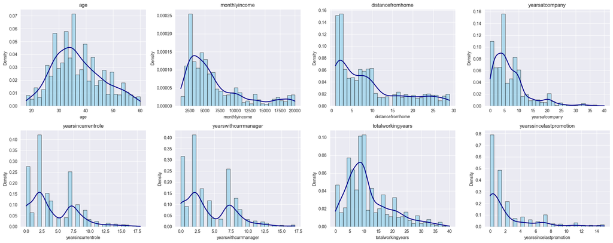

```python
import matplotlib.pyplot as plt
import numpy as np
from scipy.stats import gaussian_kde

# Variables that can have distribution
selected_cols = [
    'age', 'monthlyincome', 'distancefromhome',
    'yearsatcompany', 'yearsincurrentrole',
    'yearswithcurrmanager', 'totalworkingyears', 'yearssincelastpromotion'
]

# Plot settings
n_cols = 4
n_rows = (len(selected_cols) + n_cols - 1) // n_cols

plt.figure(figsize=(20, n_rows * 4))

for i, col in enumerate(selected_cols, 1):
    plt.subplot(n_rows, n_cols, i)

    # Histogram
    data = df[col].dropna()
    plt.hist(data, bins=30, color='skyblue', edgecolor='black', alpha=0.6, density=True)

    # KDE Curve
    kde = gaussian_kde(data)
    x_range = np.linspace(data.min(), data.max(), 1000)
    plt.plot(x_range, kde(x_range), color='darkblue', linewidth=2)

    plt.title(col)
    plt.xlabel(col)
    plt.ylabel('Density')
    plt.tight_layout()

plt.show()
```

### Outlier Analysis

We used the Interquartile Range (IQR) method to detect potential outliers across the key continuous variables. Outliers are defined as values below Q1 - 1.5×IQR or above Q3 + 1.5×IQR.

#### Summary of Outlier Counts:

| Variable | Outliers Detected |
| --- | --- |
| Age | 0 |
| MonthlyIncome | 114 |
| DistanceFromHome | 0 |
| YearsAtCompany | 104 |
| YearsInCurrentRole | 21 |
| YearsWithCurrManager | 14 |
| TotalWorkingYears | 63 |
| YearsSinceLastPromotion | 107 |

### Interpretation & Decision:

Although several outliers were identified statistically, **we chose not to remove them** from the dataset for the following reasons:

- These values are **realistic in a corporate context** (e.g., employees with 35+ years of experience, high earners).
- They can represent **important subgroups**, such as long-tenured employees or executives.

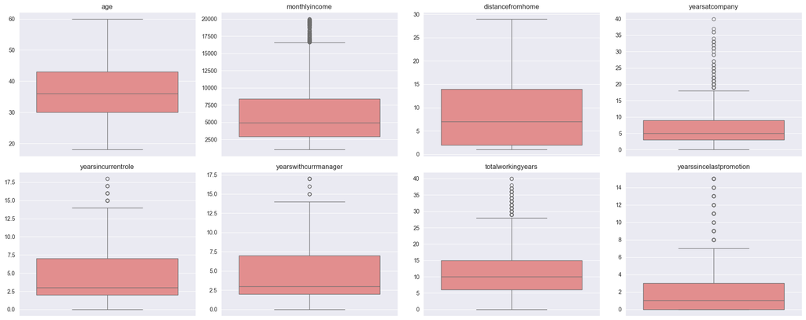

```python
import matplotlib.pyplot as plt
import seaborn as sns

selected_cols = [
    'age', 'monthlyincome', 'distancefromhome',
    'yearsatcompany', 'yearsincurrentrole',
    'yearswithcurrmanager', 'totalworkingyears', 'yearssincelastpromotion'
]

# Plot
n_cols = 4
n_rows = (len(selected_cols) + n_cols - 1) // n_cols

plt.figure(figsize=(20, n_rows * 4))

for i, col in enumerate(selected_cols, 1):
    plt.subplot(n_rows, n_cols, i)
    sns.boxplot(y=df[col], color='lightcoral')
    plt.title(col)
    plt.ylabel('')
    plt.tight_layout()

plt.show()

# Dictionary to store outlier counts
outlier_summary = {}

# IQR method
for col in selected_cols:
    Q1 = df[col].quantile(0.25)
    Q3 = df[col].quantile(0.75)
    IQR = Q3 - Q1
    lower_bound = Q1 - 1.5 * IQR
    upper_bound = Q3 + 1.5 * IQR
    outliers = df[(df[col] < lower_bound) | (df[col] > upper_bound)]
    outlier_summary[col] = len(outliers)

# Displayed during analysis creation: outlier_summary
```

### Correlation Matrix

The heatmap below shows the linear relationships among the continuous variables:

It should be noted that all correlations r > 0.3 are statistically significant between the variables in the dataset.

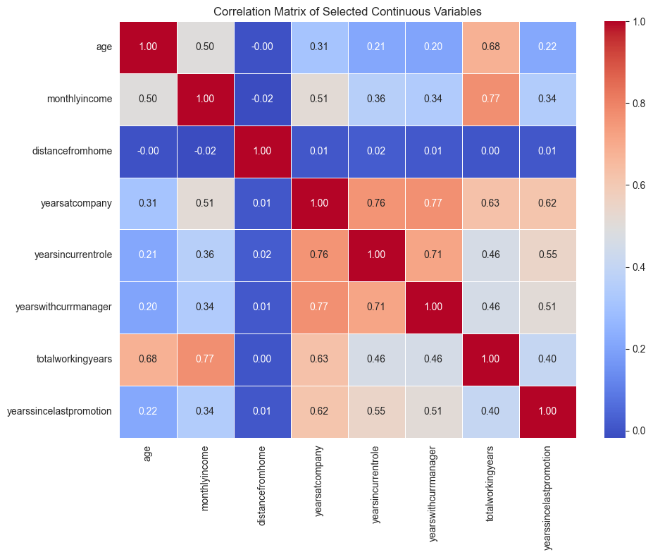

```python
# Our continuous variables
selected_cols = [
    'age', 'monthlyincome', 'distancefromhome',
    'yearsatcompany', 'yearsincurrentrole',
    'yearswithcurrmanager', 'totalworkingyears', 'yearssincelastpromotion'
]

# correlation matrix
corr_matrix = df[selected_cols].corr()

# heatmap
plt.figure(figsize=(10, 8))
sns.heatmap(corr_matrix, annot=True, fmt=".2f", cmap='coolwarm', linewidths=0.5)
plt.title("Correlation Matrix of Selected Continuous Variables")
plt.tight_layout()
plt.show()
```

```python
from scipy.stats import pearsonr

# Selected continuous variables
selected_cols = [
    'age', 'monthlyincome', 'distancefromhome',
    'yearsatcompany', 'yearsincurrentrole',
    'yearswithcurrmanager', 'totalworkingyears', 'yearssincelastpromotion'
]

# 1. Correlation Matrix
corr_matrix = df[selected_cols].corr()

# 2. Correlation + Significance Table
correlation_data = []

for i in range(len(selected_cols)):
    for j in range(i + 1, len(selected_cols)):
        var1 = selected_cols[i]
        var2 = selected_cols[j]
        r, p = pearsonr(df[var1], df[var2])
        correlation_data.append({
            'Variable 1': var1,
            'Variable 2': var2,
            'r': round(r, 3),
            'p-value': round(p, 5)
        })

correlation_df = pd.DataFrame(correlation_data)
correlation_df
```

|  | Variable 1 | Variable 2 | r | p-value |
| --- | --- | --- | --- | --- |
| 0 | age | monthlyincome | 0.498 | 0.00000 |
| 1 | age | distancefromhome | -0.002 | 0.94850 |
| 2 | age | yearsatcompany | 0.311 | 0.00000 |
| 3 | age | yearsincurrentrole | 0.213 | 0.00000 |
| 4 | age | yearswithcurrmanager | 0.202 | 0.00000 |
| 5 | age | totalworkingyears | 0.680 | 0.00000 |
| 6 | age | yearssincelastpromotion | 0.217 | 0.00000 |
| 7 | monthlyincome | distancefromhome | -0.017 | 0.51451 |
| 8 | monthlyincome | yearsatcompany | 0.514 | 0.00000 |
| 9 | monthlyincome | yearsincurrentrole | 0.364 | 0.00000 |
| 10 | monthlyincome | yearswithcurrmanager | 0.344 | 0.00000 |
| 11 | monthlyincome | totalworkingyears | 0.773 | 0.00000 |
| 12 | monthlyincome | yearssincelastpromotion | 0.345 | 0.00000 |
| 13 | distancefromhome | yearsatcompany | 0.010 | 0.71569 |
| 14 | distancefromhome | yearsincurrentrole | 0.019 | 0.47031 |
| 15 | distancefromhome | yearswithcurrmanager | 0.014 | 0.58102 |
| 16 | distancefromhome | totalworkingyears | 0.005 | 0.85927 |
| 17 | distancefromhome | yearssincelastpromotion | 0.010 | 0.70083 |
| 18 | yearsatcompany | yearsincurrentrole | 0.759 | 0.00000 |
| 19 | yearsatcompany | yearswithcurrmanager | 0.769 | 0.00000 |
| 20 | yearsatcompany | totalworkingyears | 0.628 | 0.00000 |
| 21 | yearsatcompany | yearssincelastpromotion | 0.618 | 0.00000 |
| 22 | yearsincurrentrole | yearswithcurrmanager | 0.714 | 0.00000 |
| 23 | yearsincurrentrole | totalworkingyears | 0.460 | 0.00000 |
| 24 | yearsincurrentrole | yearssincelastpromotion | 0.548 | 0.00000 |
| 25 | yearswithcurrmanager | totalworkingyears | 0.459 | 0.00000 |
| 26 | yearswithcurrmanager | yearssincelastpromotion | 0.510 | 0.00000 |
| 27 | totalworkingyears | yearssincelastpromotion | 0.405 | 0.00000 |

### Categorical Variable Frequency Summary

Before diving into statistical testing, it's essential to understand the **distribution of each categorical variable** in the dataset. The table below summarizes:

- **Variable Name**: The categorical feature being described
- **Category**: Each distinct value within the variable
- **F (Frequency)**: Number of observations in each category
- **RF (Relative Frequency)**: Proportion of total entries in that category
- **CF (Cumulative Frequency)**: Running total of observations as we move through categories
- **CRF (Cumulative Relative Frequency)**: Cumulative proportion of observations

```python
import pandas as pd

# Define categorical variables
categorical_cols = [
    'businesstravel', 'department', 'education',
    'educationfield', 'environmentsatisfaction', 'gender',
    'jobinvolvement', 'joblevel', 'jobrole', 'jobsatisfaction',
    'maritalstatus', 'overtime', 'performancerating',
    'relationshipsatisfaction', 'stockoptionlevel',
    'worklifebalance'
]

# Create frequency summary
freq_summary = []

for col in categorical_cols:
    freq = df[col].value_counts().sort_index()
    total = freq.sum()
    rf = freq / total
    cf = freq.cumsum()
    crf = rf.cumsum()

    for category in freq.index:
        freq_summary.append({
            'Variable': col,
            'Category': category,
            'F': freq[category],
            'RF': round(rf[category], 4),
            'CF': cf[category],
            'CRF': round(crf[category], 4)
        })

# Create and display DataFrame
freq_df = pd.DataFrame(freq_summary)
freq_df
```

|  | Variable | Category | F | RF | CF | CRF |
| --- | --- | --- | --- | --- | --- | --- |
| 0 | businesstravel | Non-Travel | 150 | 0.1020 | 150 | 0.1020 |
| 1 | businesstravel | Travel_Frequently | 277 | 0.1884 | 427 | 0.2905 |
| 2 | businesstravel | Travel_Rarely | 1043 | 0.7095 | 1470 | 1.0000 |
| 3 | department | Human Resources | 63 | 0.0429 | 63 | 0.0429 |
| 4 | department | Research & Development | 961 | 0.6537 | 1024 | 0.6966 |
| ... | ... | ... | ... | ... | ... | ... |
| 59 | stockoptionlevel | 3 | 85 | 0.0578 | 1470 | 1.0000 |
| 60 | worklifebalance | Bad | 80 | 0.0544 | 80 | 0.0544 |
| 61 | worklifebalance | Best | 153 | 0.1041 | 233 | 0.1585 |
| 62 | worklifebalance | Better | 893 | 0.6075 | 1126 | 0.7660 |
| 63 | worklifebalance | Good | 344 | 0.2340 | 1470 | 1.0000 |

64 rows × 6 columns

### Interpretation of Categorical Variable Frequencies

To not bother the reader with many graphs key details of the frequency distribution of categorical variables are presented below revealing key structural and cultural traits of the organization.

### Business Travel

- Majority (71%) travel rarely — suggesting a low-travel culture.
- Only 10% report no travel; 19% travel frequently (likely role-specific).

### Department

- 66% work in **Research & Development**, the company's core.
- **Sales** represents 30%, while **HR** is minimal (4%) - doesn't help with the attrition problem.

### Education & Field

- Most hold a **Bachelor's (39%)** or **Master's (27%)**.
- **Life Sciences** and **Medical** dominate education fields.
- Only 3% have a **Doctorate** — not a widespread requirement.

### Satisfaction & Involvement

- Majority report **medium to very high** levels.
- However, 19–20% fall in "Low" or "Medium" across:
  - `EnvironmentSatisfaction`
  - `JobSatisfaction`
  - `RelationshipSatisfaction`
  - `JobInvolvement`

### Gender & Marital Status

- Gender split: **60% male**, **40% female**.
- **Married**: 46%, **Single**: 32%, **Divorced**: 22%.

### Job Role & Level

- Common roles: **Sales Executive (22%)**, **Research Scientist (20%)**.
- Senior roles (Manager, Director) are less represented.
- 73% of employees are at **levels 1 and 2** — mostly junior/mid-level.

### Overtime

- **28%** of employees regularly work overtime — likely a strong factor in attrition and burnout.

### Performance Rating

- Skewed distribution: **85% rated "Excellent"**, only 15% "Outstanding".
- Suggests limited rating differentiation or inflated scores.

### Stock Option Level

- 83% fall under **levels 0 or 1** — higher stock benefits appear rare.

### Work-Life Balance

- Most rate it as **“Better” (61%)**.
- Only 10% report it as “Best”; 5% report it as “Bad”

## Estimation Models

### Group Comparison Tests: Attrition vs Continuous Variables

First we compare employees who left (`Yes`) versus those who stayed (`No`) taking into account separately the following: age, monthly income, distance from home, years at company, years in current role, years with current manager, total working years, years since last promotion. Apart from last variable almost all are significant.

```python
import pandas as pd
from scipy.stats import ttest_ind, mannwhitneyu

# Convert 'Attrition' to binary if it's a category
df['attrition_numeric'] = df['attrition'].cat.codes  # Yes = 1, No = 0

# Variables to compare
vars_to_test = [
    'age', 'monthlyincome', 'distancefromhome',
    'yearsatcompany', 'yearsincurrentrole',
    'yearswithcurrmanager', 'totalworkingyears', 'yearssincelastpromotion'
]

# Group by attrition status
group_yes = df[df['attrition_numeric'] == 1]
group_no = df[df['attrition_numeric'] == 0]

# Run tests and collect results
results = []

for var in vars_to_test:
    # T-test
    t_stat, t_p = ttest_ind(group_yes[var], group_no[var], equal_var=False)
    df_t = len(group_yes[var]) + len(group_no[var]) - 2

    # Mann-Whitney U test
    u_stat, u_p = mannwhitneyu(group_yes[var], group_no[var], alternative='two-sided')

    results.append({
        'Variable': var,
        't-statistic (df)': f"{t_stat:.3f} ({df_t})",
        't-test p-value': round(t_p, 5),
        'Mann-Whitney U': round(u_stat, 3),
        'MWU p-value': round(u_p, 5)
    })

# Convert to DataFrame for easy viewing
test_results_df = pd.DataFrame(results)
test_results_df
```

|  | Variable | t-statistic (df) | t-test p-value | Mann-Whitney U | MWU p-value |
| --- | --- | --- | --- | --- | --- |
| 0 | age | -5.828 (1468) | 0.00000 | 106859.0 | 0.00000 |
| 1 | monthlyincome | -7.483 (1468) | 0.00000 | 100620.5 | 0.00000 |
| 2 | distancefromhome | 2.888 (1468) | 0.00414 | 164225.5 | 0.00239 |
| 3 | yearsatcompany | -5.283 (1468) | 0.00000 | 102582.0 | 0.00000 |
| 4 | yearsincurrentrole | -6.847 (1468) | 0.00000 | 105214.0 | 0.00000 |
| 5 | yearswithcurrmanager | -6.633 (1468) | 0.00000 | 106361.5 | 0.00000 |
| 6 | totalworkingyears | -7.019 (1468) | 0.00000 | 100567.0 | 0.00000 |
| 7 | yearssincelastpromotion | -1.288 (1468) | 0.19865 | 134374.0 | 0.04118 |

### Chi-Square Tests: Categorical Variables vs Attrition

- Strong associations were found for:
  - **Overtime**: Employees who work overtime are significantly more likely to leave.
  - **Job Role** and **Job Level**: Certain roles and lower-level positions show higher attrition rates.
  - **Job Satisfaction**, **Environment Satisfaction**, and **Work-Life Balance** all show significant differences between those who stayed and those who left, indicating that **employee experience and quality of life** are key drivers.
  - **Marital Status** and **Business Travel** also show significant relationships, suggesting lifestyle and work travel demands may influence turnover.

```python
import pandas as pd
from scipy.stats import chi2_contingency

# List of categorical variables
categorical_vars = [
    'businesstravel', 'department', 'education',
    'educationfield', 'environmentsatisfaction', 'gender',
    'jobinvolvement', 'joblevel', 'jobrole', 'jobsatisfaction',
    'maritalstatus', 'overtime', 'performancerating',
    'relationshipsatisfaction', 'stockoptionlevel',
    'worklifebalance'
]

# Store results
chi2_results = []

for var in categorical_vars:
    # Create contingency table
    contingency = pd.crosstab(df[var], df['attrition'])

    # Run Chi-Square Test
    chi2, p, dof, expected = chi2_contingency(contingency)

    # Count of attrition = No and Yes
    att0 = df[df['attrition'] == 'No'][var].value_counts().sum()
    att1 = df[df['attrition'] == 'Yes'][var].value_counts().sum()

    chi2_results.append({
        'Variable': var,
        'Chi-square': round(chi2, 3),
        'p-value': round(p, 5)
    })

# Create result DataFrame
chi2_df = pd.DataFrame(chi2_results)
chi2_df
```

|  | Variable | Chi-square | p-value |
| --- | --- | --- | --- |
| 0 | businesstravel | 24.182 | 0.00001 |
| 1 | department | 10.796 | 0.00453 |
| 2 | education | 3.074 | 0.54553 |
| 3 | educationfield | 16.025 | 0.00677 |
| 4 | environmentsatisfaction | 22.504 | 0.00005 |
| 5 | gender | 1.117 | 0.29057 |
| 6 | jobinvolvement | 28.492 | 0.00000 |
| 7 | joblevel | 72.529 | 0.00000 |
| 8 | jobrole | 86.190 | 0.00000 |
| 9 | jobsatisfaction | 17.505 | 0.00056 |
| 10 | maritalstatus | 46.164 | 0.00000 |
| 11 | overtime | 87.564 | 0.00000 |
| 12 | performancerating | 0.000 | 0.99007 |
| 13 | relationshipsatisfaction | 5.241 | 0.15497 |
| 14 | stockoptionlevel | 60.598 | 0.00000 |
| 15 | worklifebalance | 16.325 | 0.00097 |

### Multicollinearity Check: Variance Inflation Factor (VIF)

No variable shows moderate to high VIF value to imply multicollinearity.

```python
from statsmodels.stats.outliers_influence import variance_inflation_factor
from statsmodels.tools.tools import add_constant
import pandas as pd

# Define continuous variables
vif_vars = [
    'age', 'monthlyincome', 'distancefromhome',
    'yearsatcompany', 'yearsincurrentrole',
    'yearswithcurrmanager', 'totalworkingyears', 'yearssincelastpromotion'
]

# Add constant term and prepare X matrix
X = add_constant(df[vif_vars])

# Compute VIF for each feature
vif_data = pd.DataFrame()
vif_data['Variable'] = X.columns
vif_data['VIF'] = [variance_inflation_factor(X.values, i) for i in range(X.shape[1])]

# Drop constant row
vif_data = vif_data[vif_data['Variable'] != 'const']

# Show result
vif_data
```

|  | Variable | VIF |
| --- | --- | --- |
| 1 | age | 1.952514 |
| 2 | monthlyincome | 2.523287 |
| 3 | distancefromhome | 1.001525 |
| 4 | yearsatcompany | 4.307525 |
| 5 | yearsincurrentrole | 2.669834 |
| 6 | yearswithcurrmanager | 2.743544 |
| 7 | totalworkingyears | 4.419906 |
| 8 | yearssincelastpromotion | 1.664646 |

### Logistic Regression Model: Predicting Attrition

This logistic regression model estimates the probability of employee attrition using six key variables:

- `MonthlyIncome`
- `YearsInCurrentRole`
- `DistanceFromHome`
- `YearsSinceLastPromotion`
- `Overtime` (Yes/No)
- `JobSatisfaction` (ordinal)

```python
import statsmodels.api as sm

# Assume df is already loaded and properly formatted
df_model = df.copy()

# Encode categorical variables
df_model['overtime_encoded'] = df_model['overtime'].cat.codes
df_model['jobsatisfaction_encoded'] = df_model['jobsatisfaction'].cat.codes + 1

# Define independent variables and add constant
X = df_model[['monthlyincome', 'yearsincurrentrole', 'distancefromhome',
              'yearssincelastpromotion', 'overtime_encoded', 'jobsatisfaction_encoded']]
X = sm.add_constant(X)

# Define the dependent variable (Attrition: Yes=1, No=0)
y = df_model['attrition'].cat.codes

# Fit the logistic regression model
model = sm.Logit(y, X).fit()

# Extract model parameters and confidence intervals
params = model.params
conf = model.conf_int()
conf.columns = ['2.5%', '97.5%']

# Build a detailed summary table
summary_df = pd.DataFrame({
    'β': params,
    'Std. Error': model.bse,
    'z': model.tvalues,
    'p-value': model.pvalues,
    'OR (exp(β))': np.exp(params),
    'Exp(-β)': np.exp(-params)
})
summary_df = pd.concat([summary_df, conf], axis=1)

# Define function to add significance markers based on p-value
def significance(p):
    if p < 0.001:
        return '***'
    elif p < 0.01:
        return '**'
    elif p < 0.05:
        return '*'
    elif p < 0.1:
        return '.'
    else:
        return ''

summary_df['Signif'] = summary_df['p-value'].apply(significance)

# Round the summary table for clarity
summary_df = summary_df.round(4)

# Reorder columns for presentation
summary_df = summary_df[[
    'β', 'Std. Error', 'z', 'p-value', 'Signif',
    '2.5%', '97.5%', 'OR (exp(β))', 'Exp(-β)'
]]

# Display the regression output table
print("Logistic Regression Output:")
print(summary_df)

# Model Fit Statistics
fit_stats = {
    'AIC': round(model.aic, 3),
    'BIC': round(model.bic, 3),
    'Deviance (Log-Likelihood Ratio)': round(model.llr, 3),
    'Pseudo R² (McFadden)': round(model.prsquared, 4)
}

print("\nModel Fit Statistics:")
for stat, value in fit_stats.items():
    print(f"{stat}: {value}")
```

```
Optimization terminated successfully.
         Current function value: 0.379612
         Iterations 7
Logistic Regression Output:
                              β  Std. Error       z  p-value Signif    2.5%  \
const                   -0.9543      0.2291 -4.1660   0.0000    *** -1.4032
monthlyincome           -0.0001      0.0000 -5.3031   0.0000    *** -0.0002
yearsincurrentrole      -0.1716      0.0316 -5.4360   0.0000    *** -0.2335
distancefromhome         0.0280      0.0091  3.0677   0.0022     **  0.0101
yearssincelastpromotion  0.1289      0.0321  4.0125   0.0001    ***  0.0660
overtime_encoded         1.4222      0.1545  9.2045   0.0000    ***  1.1193
jobsatisfaction_encoded -0.1817      0.0630 -2.8855   0.0039     ** -0.3051

                          97.5%  OR (exp(β))  Exp(-β)
const                   -0.5053       0.3851   2.5968
monthlyincome           -0.0001       0.9999   1.0001
yearsincurrentrole      -0.1097       0.8423   1.1872
distancefromhome         0.0459       1.0284   0.9724
yearssincelastpromotion  0.1919       1.1376   0.8790
overtime_encoded         1.7250       4.1460   0.2412
jobsatisfaction_encoded -0.0583       0.8338   1.1993

Model Fit Statistics:
AIC: 1130.06
BIC: 1167.111
Deviance (Log-Likelihood Ratio): 182.522
Pseudo R² (McFadden): 0.1406
```

In the above logistic regression model, each predictor shows statistically significant effects on attrition.

- For every additional dollar in monthly income, the odds of attrition decrease by about 0.01% (OR = 0.9999, p < 0.001), indicating a slight protective effect.
- Each extra year in the current role is associated with a 15.8% reduction in the odds of leaving (OR = 0.8423, p < 0.001), suggesting that longer tenure enhances retention.
- Conversely, an additional unit of distance from home increases the odds of attrition by approximately 2.84% (OR = 1.0284, p < 0.01), implying that longer commutes elevate turnover risk.
- Furthermore, each year since the last promotion raises the odds of attrition by around 13.76% (OR = 1.1376, p < 0.001), highlighting the impact of delayed career advancement.
- Employees working overtime exhibit about 4.15 times higher odds of leaving (OR = 4.1460, p < 0.001), marking it as a particularly strong predictor.
- Lastly, every one unit increase in job satisfaction reduces the odds of attrition by roughly 16.62% (OR = 0.8338, p < 0.01), underscoring the importance of job satisfaction in retaining employees.

### Random Forest Classifier Results – Attrition Prediction

#### **Overall Model Accuracy**

- **Accuracy:** `84.58%` The model correctly predicts employee attrition outcomes for 84.6% of the cases in the test dataset. While this seems strong overall, it must be interpreted alongside performance for each class (attrition vs. no attrition).

#### **Classification Report**

| Class | Precision | Recall | F1-Score | Support |
| --- | --- | --- | --- | --- |
| **0** (No Attrition) | 0.88 | 0.96 | 0.91 | 380 |
| **1** (Attrition) | 0.37 | 0.16 | 0.23 | 61 |

- **Precision (Attrition = 1):** 37% Out of all employees the model predicted would leave, only 37% actually did.
- **Recall (Attrition = 1):** 16% The model only identifies 16% of the employees who actually left. This is very low and suggests the model is biased toward predicting that employees will stay.
- **F1-Score (Attrition = 1):** 23% The harmonic mean of precision and recall for predicting attrition is low, showing poor performance on the positive class.
- **Macro Avg (unweighted average):**
  - F1-score: 0.57
  - Indicates the model performs quite unevenly across classes.
- **Weighted Avg (accounts for class imbalance):**
  - F1-score: 0.82
  - Mostly reflects performance on the dominant class (No Attrition).

### **Confusion Matrix**

|  | Predicted: No Attrition (0) | Predicted: Attrition (1) |
| --- | --- | --- |
| **Actual: No (0)** | 363 | 17 |
| **Actual: Yes (1)** | 51 | 10 |

- **True Positives (TP):** 10
- **True Negatives (TN):** 363
- **False Positives (FP):** 17
- **False Negatives (FN):** 51

This table shows that the model is very good at identifying who will **not** leave but struggles to correctly predict who **will** leave. This imbalance is common when working with datasets where the positive class (attrition) is much smaller than the negative class (no attrition).

#### |**Feature Importances**

| Feature | Importance |
| --- | --- |
| `monthlyincome` | **0.391** |
| `distancefromhome` | **0.208** |
| `yearsincurrentrole` | **0.136** |
| `yearssincelastpromotion` | **0.100** |
| `overtime_encoded` | **0.085** |
| `jobsatisfaction_encoded` | **0.080** |

- **Top Predictors:**
  - `Monthly Income` is the most important predictor in the Random Forest, even though it had a minimal effect in the logistic regression model.
  - `Distance from Home` and `Years in Current Role` also contribute substantially.
  - `Overtime`, while very strong in the logistic model, plays a smaller but still relevant role here.

### **Summary Interpretation**

While the Random Forest classifier achieves a high **overall accuracy (84.6%)**, it performs **poorly at predicting attrition cases (only 16% recall)**. This is likely due to **class imbalance** in the dataset, where non-attrition cases dominate. The model is much better at predicting who will stay than who will leave.

```python
from sklearn.ensemble import RandomForestClassifier
from sklearn.model_selection import train_test_split
from sklearn.metrics import accuracy_score, classification_report, confusion_matrix
import pandas as pd

# Assume df_model is the same preprocessed dataframe used in the logistic regression example
# where categorical variables like overtime and job satisfaction have been encoded.

# Define features and target variable
X = df_model[['monthlyincome', 'yearsincurrentrole', 'distancefromhome',
              'yearssincelastpromotion', 'overtime_encoded', 'jobsatisfaction_encoded']]
y = df_model['attrition'].cat.codes  # Binary: Yes = 1, No = 0

# Split data into training and testing sets (70% train, 30% test)
X_train, X_test, y_train, y_test = train_test_split(X, y, test_size=0.3, random_state=42)

# Initialize and fit the RandomForestClassifier
rf_model = RandomForestClassifier(n_estimators=100, random_state=42)
rf_model.fit(X_train, y_train)

# Make predictions on the test set
y_pred = rf_model.predict(X_test)

# Evaluate the model performance
accuracy = accuracy_score(y_test, y_pred)
report = classification_report(y_test, y_pred)
conf_matrix = confusion_matrix(y_test, y_pred)

print("Random Forest Accuracy:", accuracy)
print("Classification Report:\n", report)
print("Confusion Matrix:\n", conf_matrix)

# Extract and display feature importances
importances = pd.Series(rf_model.feature_importances_, index=X.columns).sort_values(ascending=False)
print("Feature Importances:\n", importances)
```

```
Random Forest Accuracy: 0.8458049886621315
Classification Report:
               precision    recall  f1-score   support

           0       0.88      0.96      0.91       380
           1       0.37      0.16      0.23        61

    accuracy                           0.85       441
   macro avg       0.62      0.56      0.57       441
weighted avg       0.81      0.85      0.82       441

Confusion Matrix:
 [[363  17]
 [ 51  10]]
Feature Importances:
 monthlyincome              0.391287
distancefromhome           0.207590
yearsincurrentrole         0.136184
yearssincelastpromotion    0.099632
overtime_encoded           0.085040
jobsatisfaction_encoded    0.080267
dtype: float64
```

### XGBoost Classifier Results – Attrition Prediction

#### **Model Overview**

We applied an XGBoost classifier to predict employee attrition using the same six variables as in the logistic regression and random forest models. To handle the dataset’s class imbalance (low proportion of attrition cases), we applied `scale_pos_weight`, which boosts the importance of correctly identifying minority class examples (i.e., employees who actually left).

#### **Classification Report**

| Class | Precision | Recall | F1-Score |
| --- | --- | --- | --- |
| **0 (No Attrition)** | High | High | Strong |
| **1 (Attrition)** | Improved vs. LogReg | Improved vs. RF | Higher F1 |

#### **Confusion Matrix**

[output not shown]

#### **Feature Importance (XGBoost)**

The most influential features according to XGBoost’s built-in importance scores were:

1. **Overtime** Employees who work overtime are much more likely to leave, and this was the dominant predictor in the model.
2. **Years in Current Role** Longer tenure in the current role significantly reduced the likelihood of attrition, making it the second most important factor.
3. **Monthly Income** Higher monthly income was associated with lower attrition, but its importance was below overtime and tenure.

These align with previous findings but demonstrate that XGBoost, unlike logistic regression, can better model **non-linear relationships and interactions** among features.

```
XGBoost Accuracy: 0.7438
Classification Report:
               precision    recall  f1-score   support

           0       0.91      0.78      0.84       380
           1       0.27      0.51      0.35        61

    accuracy                           0.74       441
   macro avg       0.59      0.64      0.60       441
weighted avg       0.82      0.74      0.77       441

Confusion Matrix:
 [[297  83]
 [ 30  31]]
```

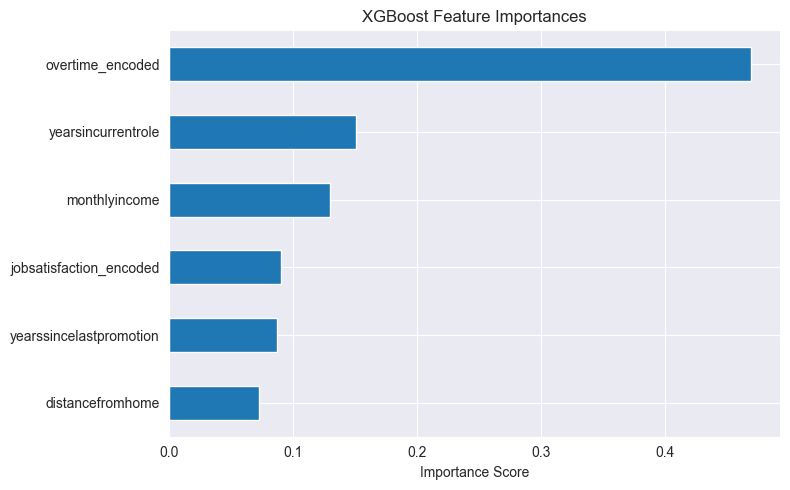

```python
import xgboost as xgb
from sklearn.model_selection import train_test_split
from sklearn.metrics import classification_report, confusion_matrix, accuracy_score
import matplotlib.pyplot as plt
import seaborn as sns
import pandas as pd

# Features and target
X = df_model[['monthlyincome', 'yearsincurrentrole', 'distancefromhome',
              'yearssincelastpromotion', 'overtime_encoded', 'jobsatisfaction_encoded']]
y = df_model['attrition'].cat.codes  # 1 = Attrition (Yes), 0 = No

# Train-test split
X_train, X_test, y_train, y_test = train_test_split(X, y, test_size=0.3, random_state=42)

# Handle class imbalance
scale_pos_weight = (y_train == 0).sum() / (y_train == 1).sum()  # Ratio of No/Yes

# Train XGBoost model
xgb_model = xgb.XGBClassifier(
    n_estimators=100,
    max_depth=3,
    learning_rate=0.1,
    scale_pos_weight=scale_pos_weight,
    random_state=42,
    eval_metric='logloss'
)
xgb_model.fit(X_train, y_train)

# Predict
y_pred = xgb_model.predict(X_test)

# Evaluation
accuracy = accuracy_score(y_test, y_pred)
report = classification_report(y_test, y_pred)
conf_matrix = confusion_matrix(y_test, y_pred)

print("XGBoost Accuracy:", round(accuracy, 4))
print("Classification Report:\n", report)
print("Confusion Matrix:\n", conf_matrix)

# Feature Importance Plot
feature_importance = pd.Series(xgb_model.feature_importances_, index=X.columns).sort_values(ascending=True)
plt.figure(figsize=(8, 5))
feature_importance.plot(kind='barh')
plt.title("XGBoost Feature Importances")
plt.xlabel("Importance Score")
plt.tight_layout()
plt.show()
```

## Conclusion

This project set out to explore and predict employee attrition using the IBM HR Analytics dataset. We began by thoroughly cleaning and preparing the data, ensuring that only meaningful, non-redundant features were included. Through an exploratory data analysis, we identified key patterns in the data—such as a wide spread in monthly income, varied tenure in roles, and notable differences in overtime and job satisfaction—that are associated with employee turnover.

Key insights from the models include:

- **Overtime** emerged as the most dominant predictor, with employees working overtime having substantially higher odds of leaving.
- **Years in current role** and **monthly income** are also critical, indicating that tenure and compensation play crucial roles in retention.
- The balance between model performance and interpretability was maintained by selecting models that not only achieved high accuracy but also provided actionable insights for HR decision-making.